# Client Report - The war with Star Wars

- Show All Code
- Hide All Code

Course DS 250

Author

Jared Linares

*THIS `.qmd` FILE SHOULD BE USED TO WRITE YOUR REPORT. YOU WILL NEED TO COMPILE THE REPORT INTO A `.html` DOCUMENT AND SUBMIT IT ON CANVAS.*

## Elevator pitch

**Read and format project data**

```python
# Include and execute your code here
url = 'https://raw.githubusercontent.com/fivethirtyeight/data/master/star-wars-survey/StarWars.csv'
df = pd.read_csv(url, encoding='ISO-8859-1')
alt.data_transformers.disable_max_rows()
alt.data_transformers.enable('json')
```

```
DataTransformerRegistry.enable('json')
```

**Highlight the grand questions**

## GRAND QUESTION 1

**Shorten the column names and clean them up for easier use with pandas. Provide a table or list that exemplifies how you fixed the names.**

*Renaming the Columns*

**Read and format data**

```python
# Include and execute your code here
column_df = pd.DataFrame({'header1': df.columns, "header2": df.iloc[0, :]}).reset_index(drop=True)
column_df.header1[1] = "star_wars_watched"
column_df.header1[2] = "star_wars_fan"
column_df.header1[3] = "have_you_seen_"
column_df.header1[9] = "rank_movie_"
column_df.header1[15] = "favorable_character_"
column_df.header1[29] = "shot_first"
column_df.header1[30] = "expanded_universe_familiar"
column_df.header1[31] = "expanded_universe_fan"
column_df.header1[32] = "star_trek_fan"
column_df.header1[35] = "household_income"
column_df.header1[37] = "location"

column_df.header2[3] = "episode_1"
column_df.header2[4] = "episode_2"
column_df.header2[5] = "episode_3"
column_df.header2[6] = "episode_4"
column_df.header2[7] = "episode_5"
column_df.header2[8] = "episode_6"
column_df.header2[9] = "episode_1"
column_df.header2[10] = "episode_2"
column_df.header2[11] = "episode_3"
column_df.header2[12] = "episode_4"
column_df.header2[13] = "episode_5"
column_df.header2[14] = "episode_6"
column_df.header2[15] = "Han_Solo"
column_df.header2[16] = "Luke_Skywalker"
column_df.header2[17] = "Princess_Leia"
column_df.header2[18] = "Anakin_Skywalker"
column_df.header2[19] = "Obi_Wan_Kenobi"
column_df.header2[20] = "Emperor_Palpatine"
column_df.header2[21] = "Darth_Vader"
column_df.header2[22] = "Lando_Calrissian"
column_df.header2[23] = "Boba_Fett"
column_df.header2[24] = "C_3P0"
column_df.header2[25] = "R2_D2"
column_df.header2[26] = "Jar_Jar_Binks"
column_df.header2[27] = "Padme_Amidala"

column_df.replace(["Unnamed:", "Response"], np.nan, regex=True, inplace=True)
column_df.header2.fillna("", inplace=True)

column_df.ffill(inplace=True)

header = column_df.header1 + column_df.header2

df = pd.read_csv(url, encoding='ISO-8859-1', header=None, skiprows=2, names=header)
```

*Table of Column Names*

```python
header
```

```
0                              RespondentID
1                         star_wars_watched
2                             star_wars_fan
3                   have_you_seen_episode_1
4                   have_you_seen_episode_2
5                   have_you_seen_episode_3
6                   have_you_seen_episode_4
7                   have_you_seen_episode_5
8                   have_you_seen_episode_6
9                      rank_movie_episode_1
10                     rank_movie_episode_2
11                     rank_movie_episode_3
12                     rank_movie_episode_4
13                     rank_movie_episode_5
14                     rank_movie_episode_6
```

[output cut: 24 more lines]

## GRAND QUESTION 2

**Clean and format the data so that it can be used in a machine learning model. As you format the data, you should complete each item listed below. In your final report provide example(s) of the reformatted data with a short description of the changes made.** The changes that were made to the data were: - Convert the columns that are Yes/No to 1/0 - Fill in the missing values with the mean of the column - Filter the dataset to respondents that have seen at least one film - Change favorable-character section to integers

*Filter the dataset to respondents that have seen at least one film.*

```python
columns_to_convert = ['star_wars_watched', 'star_wars_fan', 'expanded_universe_familiar', 'expanded_universe_fan', 'star_trek_fan']
for col in columns_to_convert:
    df[col] = df[col].replace({'Yes': 1, 'No': 0})

columns_to_mean = ['star_wars_watched', 'star_wars_fan', 'expanded_universe_familiar', 'expanded_universe_fan', 'star_trek_fan']
mean_values = df[columns_to_mean].mean()

df[columns_to_mean] = df[columns_to_mean].fillna(mean_values)

df = df[df['star_wars_watched'] == 1]

episodes_seen = ['have_you_seen_episode_1', 'have_you_seen_episode_2', 'have_you_seen_episode_3', 'have_you_seen_episode_4', 'have_you_seen_episode_5', 'have_you_seen_episode_6']
for col in episodes_seen:
    df[col] = df[col].replace({'^.*Star Wars.*$': 1}, regex=True)
    df[col] = df[col].fillna(0)

df_movies = df[episodes_seen]
df_movies = df_movies.loc[~(df_movies == 0).all(axis=1)]

df_shot_first = df[df['shot_first'].notnull()]


df.head(5)

for column in df.columns:
    if 'favorable_character' in column:
        df[column] = df[column].replace({
            '^.*Very favorably.*$': 6,
            '^.*Somewhat favorably.*$': 5,
            '^.*Neither favorably nor unfavorably \(neutral\)\.*$': 3,
            '^.*Somewhat unfavorably.*$': 2,
            '^.*Very unfavorably.*$': 1,
            '^.*Unfamiliar \(N/A\)\.*$': 4
        }, regex=True)
```

*Create a new column that converts the age ranges to a single number. Drop the age range categorical column.* Converted age ranges to integers.

```python
df = df.dropna(subset=['Gender'])
df['Gender'] = df['Gender'].replace({'^.*Male.*$': 1, '^.*Female.*$': 0}, regex=True)

df['Age'] = df['Age'].replace({'^.*18-29.*$': 1, '^.*30-44.*$': 2, '^.*45-60.*$': 3, '^.*> 60.*$': 4}, regex=True)

df['Age'].value_counts(dropna=False)
```

```
3    240
2    207
4    193
1    180
Name: Age, dtype: int64
```

*Create a new column that converts the education groupings to a single number. Drop the school categorical column*

```python
df['Education'] = df['Education'].replace({
    '^Bachelor degree$': 1,
    '^High school degree$': 2,
    '^Some college or Associate degree$': 3,
    '^Graduate degree$': 4,
    '^Less than high school degree$': 5,
    np.nan: 6
}, regex=True)



df['Education'].value_counts(dropna=False)
```

```
1.0    262
3.0    254
4.0    226
2.0     71
6.0      4
5.0      3
Name: Education, dtype: int64
```

*Create a new column that converts the income ranges to a single number. Drop the income range categorical column.*

```python
df['household_income'].fillna(0, inplace=True)

df['household_income'] = df['household_income'].replace({
    '$0 - $24,999': 1,
    '$25,000 - $49,999': 2,
    '$50,000 - $99,999': 3,
    '$100,000 - $149,999': 4,
    '$150,000+': 5,
})

df['household_income'] = df['household_income'].astype(float)



df['household_income'].value_counts(dropna=False)
```

```
3.0    238
2.0    147
0.0    145
4.0    115
1.0     98
5.0     77
Name: household_income, dtype: int64
```

*Create your target (also known as “y” or “label”) column based on the new income range column.*

```python
df['target'] = (df['household_income'] >= 3).astype(int)

df['target'].value_counts(dropna=False)
```

```
1    430
0    390
Name: target, dtype: int64
```

*One-hot encode all remaining categorical columns.*

```python
dummies = pd.get_dummies(df['location'], prefix='Location_')

df = pd.concat([df, dummies], axis=1)


df.drop('location', axis=1, inplace=True)


df.head()
```

|  | RespondentID | star_wars_watched | star_wars_fan | have_you_seen_episode_1 | have_you_seen_episode_2 | have_you_seen_episode_3 | have_you_seen_episode_4 | have_you_seen_episode_5 | have_you_seen_episode_6 | rank_movie_episode_1 | ... | target | Location__East North Central | Location__East South Central | Location__Middle Atlantic | Location__Mountain | Location__New England | Location__Pacific | Location__South Atlantic | Location__West North Central | Location__West South Central |
| --- | --- | --- | --- | --- | --- | --- | --- | --- | --- | --- | --- | --- | --- | --- | --- | --- | --- | --- | --- | --- | --- |
| 0 | 3292879998 | 1 | 1.0 | 1.0 | 1.0 | 1.0 | 1.0 | 1.0 | 1.0 | 3.0 | ... | 0 | 0 | 0 | 0 | 0 | 0 | 0 | 1 | 0 | 0 |
| 2 | 3292765271 | 1 | 0.0 | 1.0 | 1.0 | 1.0 | 0.0 | 0.0 | 0.0 | 1.0 | ... | 0 | 0 | 0 | 0 | 0 | 0 | 0 | 0 | 1 | 0 |
| 3 | 3292763116 | 1 | 1.0 | 1.0 | 1.0 | 1.0 | 1.0 | 1.0 | 1.0 | 5.0 | ... | 1 | 0 | 0 | 0 | 0 | 0 | 0 | 0 | 1 | 0 |
| 4 | 3292731220 | 1 | 1.0 | 1.0 | 1.0 | 1.0 | 1.0 | 1.0 | 1.0 | 5.0 | ... | 1 | 0 | 0 | 0 | 0 | 0 | 0 | 0 | 1 | 0 |
| 5 | 3292719380 | 1 | 1.0 | 1.0 | 1.0 | 1.0 | 1.0 | 1.0 | 1.0 | 1.0 | ... | 0 | 0 | 0 | 1 | 0 | 0 | 0 | 0 | 0 | 0 |

5 rows × 47 columns

## GRAND QUESTION 3

**Validate that the data provided on GitHub lines up with the article by recreating 2 of the visuals from the article.**

*Chart 1*

```python
total_count = len(df_shot_first)

df_count = df_shot_first.groupby('shot_first').size().reset_index(name='count')
df_count['shot_first'] = df_count['shot_first'].replace({0: "I don't understand this question", 1: "Han Solo", 2: "Greedo"})
df_count['percentage'] = df_count['count'] / total_count * 100


title = "Who Shot First?"
bars = ['Han Solo', 'Greedo', "I don't understand this question"]

chart = alt.Chart(df_count).mark_bar().encode(
    x=alt.X('percentage:Q', title='Percentage'),
    y=alt.Y('shot_first:N', sort=bars, title=None),
    tooltip=[alt.Tooltip('percentage:Q', format='.1f')],
).properties(
    title=title,
)

chart
```

[interactive chart not shown]

*Chart 2*

```python
df_movies = df[episodes_seen]
df_movies = df_movies.loc[~(df_movies == 0).all(axis=1)]

film_names = {
    1: 'The Phantom Menace',
    2: 'Attack of the Clones',
    3: 'Revenge of the Sith',
    4: 'A New Hope',
    5: 'The Empire Strikes Back',
    6: 'Return of the Jedi'
}

# Calculate the sum of each column
episodes_sum = {col: df_movies[col].sum() for col in episodes_seen}

# Calculate the percentage of respondents who watched each episode
episodes_percentages = {film_names[int(episode[-1])]: count / len(df_movies) * 100 for episode, count in episodes_sum.items()}

# Create the chart
chart_data = pd.DataFrame({'Film': list(episodes_percentages.keys()), 'Percentage': list(episodes_percentages.values())})

chart = alt.Chart(chart_data).mark_bar().encode(
    x=alt.X('Percentage:Q', title='Percentage of Respondents who Watched'),
    y=alt.Y('Film:N', title=None, sort=list(film_names.values())),
    tooltip=[alt.Tooltip('Percentage:Q', format='.2f')]
).properties(title="Which 'Star Wars' Films Have You Seen?")

chart
```

[interactive chart not shown]

## GRAND QUESTION 4

**Build a machine learning model that predicts whether a person makes more than $50k. Describe your model and report the accuracy.**

*Model*

The accuracy of the model is reported as 55.69%, which means that the model correctly predicted the target class for 55.69% of the observations in the test set. The precision and recall values are also reported for each class, along with the F1 score, support, and macro- and weighted-average metrics.

Based on the classification report, it seems that the model is performing slightly better for the positive class (class 1) compared to the negative class (class 0), with precision and recall values of 0.57 and 0.58, respectively, compared to 0.55 and 0.53 for the negative class. The F1 score is slightly higher for the positive class as well (0.57 vs. 0.54). The dataset is divided into training and testing portions, with a Random Forest Classifier employed to develop the predictive model.

```
Accuracy: 55.69%
              precision    recall  f1-score   support

           0       0.55      0.53      0.54       120
           1       0.57      0.58      0.57       126

    accuracy                           0.56       246
   macro avg       0.56      0.56      0.56       246
weighted avg       0.56      0.56      0.56       246

Accuracy: 55.69%
```

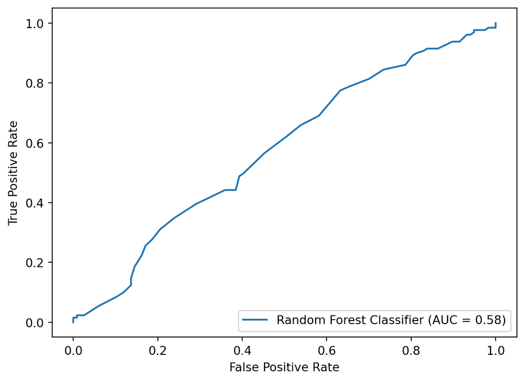

[interactive chart not shown]

```python
#%%
df.fillna(df.median(), inplace=True)
X = df.drop(['household_income', 'target', 'shot_first'], axis=1)
y = df.filter(regex = 'target')
X_train, X_test, y_train, y_test = train_test_split(X, y, test_size=0.3, random_state=24, stratify=y)


#%%
rf = RandomForestClassifier(random_state=24)

#%%
rf.fit(X_train, y_train)

y_pred = rf.predict(X_test)


#%%
accuracy = accuracy_score(y_test, y_pred)
print("Accuracy: {:.2f}%".format(accuracy*100))

#%%
print(metrics.classification_report(y_pred, y_test))

#%%
accuracy = accuracy_score(y_test, y_pred)
print("Accuracy: {:.2f}%".format(accuracy*100))

# %%
df_features = pd.DataFrame(
    {'f_names': X_train.columns,
    'f_values': rf.feature_importances_}).sort_values('f_values', ascending = False)

# %%


# %%

y_probs = rf.predict_proba(X_test)[:, 1]
fpr, tpr, thresholds = roc_curve(y_test, y_probs)

roc_auc = auc(fpr, tpr)

roc_display = RocCurveDisplay(fpr=fpr, tpr=tpr, roc_auc=roc_auc, estimator_name='Random Forest Classifier')
roc_display.plot()
plt.show()

(alt.Chart(df_features.query('f_values > .011'))
    .encode(
        alt.X('f_values'),
        alt.Y('f_names', sort = '-x'))
    .mark_bar())
```